# Homework 3

### Question 5

Specify a **logistic regression** model for classification using the `"glm"` engine. Then create a workflow. Add your model and the appropriate recipe. Finally, use `fit()` to apply your workflow to the **training** data.

*Hint: Make sure to store the results of `fit()`. You’ll need them later on.*

```r
# Step 1: Specify the glm Engine
log_reg <- logistic_reg() %>%
  set_engine("glm") %>%
  set_mode("classification")

# Step 2: Create the workflow using the LOG model and your recipe
log_wkflow <- workflow() %>%
  add_model(log_reg) %>%
  add_recipe(titanic_recipe)

# Step 3: Fit the LOG model to the training data
log_fit <- fit(log_wkflow, titanic_train)
```

### Question 6

**Repeat Question 5**, but this time specify a linear discriminant analysis model for classification using the `"MASS"` engine.

```r
# Install the discrim package if it's not already installed
# install.packages("discrim")

# Load the discrim package
library(discrim)
# Step 1: Specify the linear discriminant analysis model
lda_model <- discrim_linear() %>%
  set_engine("MASS") %>%
  set_mode("classification")

# Step 2: Create the workflow using the LDA model and your recipe
lda_workflow <- workflow() %>%
  add_model(lda_model) %>%
  add_recipe(titanic_recipe)

# Step 3: Fit the LDA model to the training data
lda_fit <- fit(lda_workflow, data = titanic_train)
```

### Question 7

**Repeat Question 5**, but this time specify a quadratic discriminant analysis model for classification using the `"MASS"` engine.

```r
# Step 1: Specify the linear discriminant analysis model
qda_model <- discrim_quad() %>%
  set_engine("MASS") %>%
  set_mode("classification")

# Step 2: Create the workflow using the LDA model and your recipe
qda_workflow <- workflow() %>%
  add_model(qda_model) %>%
  add_recipe(titanic_recipe)

# Step 3: Fit the LDA model to the training data
qda_fit <- fit(qda_workflow, data = titanic_train)
```

### Question 8

**Repeat Question 5**, but this time specify a *k*-nearest neighbors model for classification using the `"kknn"` engine. Choose a value for *k* to try.

```r
# install.packages("kknn")
library(kknn)
```

```r
# Step 1: Specify the *k*-nearest neighbors model for classification
knn_model <- nearest_neighbor(neighbors = 7) %>%
  set_engine("kknn") %>%
  set_mode("classification")

# Step 2: Create the workflow using the knn model and your recipe
knn_wflow <- workflow() %>%
  add_model(knn_model) %>%
  add_recipe(titanic_recipe)

# Step 3: Fit the knn model to the training data
knn_fit <- fit(knn_wflow, data = titanic_train)
```

### Question 9

Now you’ve fit four different models to your training data.

Use `predict()` and `bind_cols()` to generate predictions using each of these 4 models and your **training** data. Then use the metric of **area under the ROC curve** to assess the performance of each of the four models.

```r
# install.packages("pROC")
library(pROC)
# install.packages("Metrics")
```

```r
# Calculate ROC AUC for Logistic Regression
log_probs <- predict(log_fit, titanic_train, type = "prob")
log_auc <- bind_cols(titanic_train, log_probs) %>%
  roc_auc(survived, .pred_Yes)

# Calculate ROC AUC for LDA
lda_probs <- predict(lda_fit, titanic_train, type = "prob")
lda_auc <- bind_cols(titanic_train, lda_probs) %>%
  roc_auc(survived, .pred_Yes)

# Calculate ROC AUC for QDA
qda_probs <- predict(qda_fit, titanic_train, type = "prob")
qda_auc <- bind_cols(titanic_train, qda_probs) %>%
  roc_auc(survived, .pred_Yes)

# Calculate ROC AUC for KNN
knn_probs <- predict(knn_fit, titanic_train, type = "prob")
knn_auc <- bind_cols(titanic_train, knn_probs) %>%
  roc_auc(survived, .pred_Yes)

# Store the AUC results
auc_list <- bind_rows(log_auc, lda_auc, qda_auc, knn_auc) %>%
  tibble()%>%
  mutate(model = c("Log","LDA","QDA","Knn"))%>%
  select(model,.estimate)%>%
  arrange(.estimate)

auc_list
```

```
## # A tibble: 4 × 2
##   model .estimate
##   <chr>     <dbl>
## 1 QDA       0.864
## 2 LDA       0.868
## 3 Log       0.869
## 4 Knn       0.978
```

The AUC scores for the four models suggest that the K-Nearest Neighbors model (AUC of 0.978) performs significantly better at distinguishing between survivors and non-survivors on the training data compared to the other models. Logistic Regression, Linear Discriminant Analysis, and Quadratic Discriminant Analysis have similar AUC scores (around 0.86), indicating good predictive performance.

### Question 10

Fit all four models to your **testing** data and report the AUC of each model on the **testing** data. Which model achieved the highest AUC on the **testing** data?

Using your top-performing model, create a confusion matrix and visualize it. Create a plot of its ROC curve.

How did your best model perform? Compare its **training** and **testing** AUC values. If the values differ, why do you think this is so?

```r
log_test <- fit(log_fit, titanic_test)
lda_test <- fit(lda_fit, titanic_test)
qda_test <- fit(qda_fit, titanic_test)
knn_test <- fit(knn_fit, titanic_test)
# AUC
log_auc_test <- augment(log_test, titanic_test) %>%
  roc_auc(survived, .pred_Yes)

lda_auc_test <- augment(lda_test, titanic_test) %>%
  roc_auc(survived, .pred_Yes)

qda_auc_test <- augment(qda_test, titanic_test) %>%
  roc_auc(survived, .pred_Yes)

knn_auc_test <- augment(knn_test, titanic_test) %>%
  roc_auc(survived, .pred_Yes)

# Store the AUC results
auc_list <- bind_rows(log_auc_test, lda_auc_test, qda_auc_test, knn_auc_test) %>%
  tibble()%>%
  mutate(model = c("Log","LDA","QDA","Knn"))%>%
  select(model,.estimate)%>%
  arrange(.estimate)

auc_list
```

```
## # A tibble: 4 × 2
##   model .estimate
##   <chr>     <dbl>
## 1 LDA       0.847
## 2 Log       0.851
## 3 QDA       0.856
## 4 Knn       0.982
```

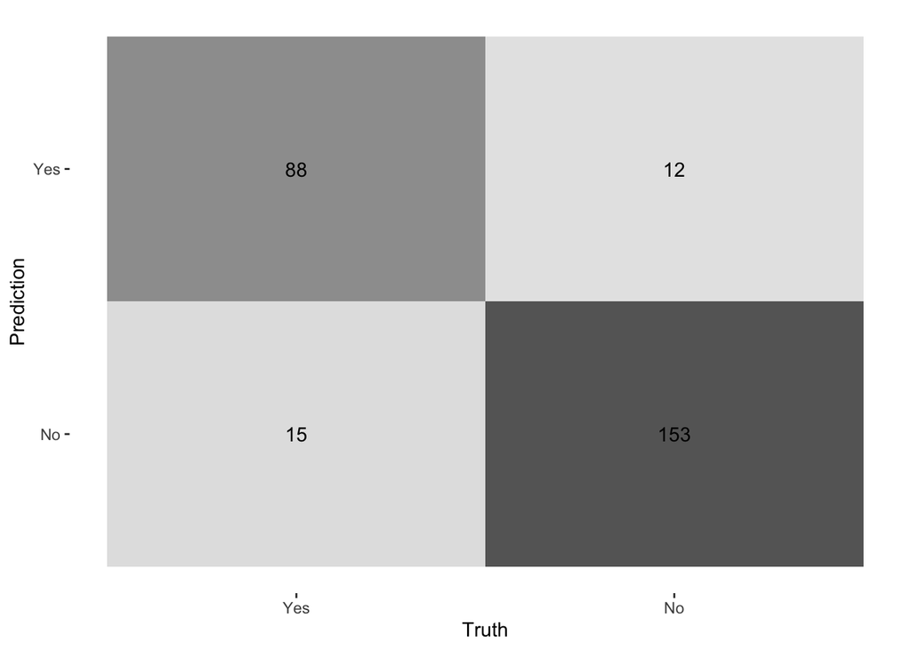

```r
# out top performance model is knn-moodel
augment(knn_test, titanic_test)%>%
conf_mat(truth = survived, estimate = .pred_class)%>%
autoplot(type = "heatmap")
```

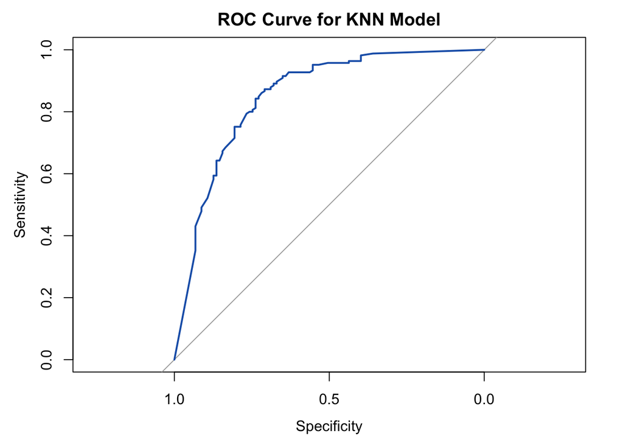

```r
library(yardstick)
library(pROC)

# Predict probabilities
knn_probs <- predict(knn_fit, titanic_test, type = "prob")
results <- bind_cols(knn_probs, titanic_test %>% select(survived))

# Calculate the ROC curve
roc_obj <- roc(response = results$survived, predictor = results$.pred_Yes)

# Plot the ROC curve
plot(roc_obj, main="ROC Curve for KNN Model", col="#1c61b6", lwd=2)
```

### Required for 231 Students

In a binary classification problem, let $p$ represent the probability of class label $1$, which implies that $1 - p$ represents the probability of class label $0$. The *logistic function* (also called the “inverse logit”) is the cumulative distribution function of the logistic distribution, which maps a real number *z* to the open interval $(0, 1)$.

### Question 11

Given that:

$$p(z)=\frac{e^z}{1+e^z}$$

Prove that the inverse of a logistic function is indeed the *logit* function:

$$z(p)=ln\left(\frac{p}{1-p}\right)$$

$$p = \frac{e^z}{1+e^z}\\
p(1+e^z) = e^z\\
p+pe^z = e^z\\
e^z(p-1)=-p\\
e^z=\frac{-p}{p-1}\\
ln(e^z)=ln(\frac{-p}{p-1})\\
z = ln(\frac{-p}{p-1}), since (p-1) < 0\\
z = ln(\frac{p}{1-p})\\
Hence, z(p)=ln\left(\frac{p}{1-p}\right)$$

### Question 12

Assume that $z = \beta_0 + \beta_{1}x_{1}$ and $p = logistic(z)$. How do the odds of the outcome change if you increase $x_{1}$ by two? Demonstrate this.
$$odds = \frac{p}{1-p},p = \frac{e^z}{1+e^z}\\
odds = e^z\\
z = \beta_0 + \beta_{1}x_{1},
z'= \beta_0 + \beta_{1}(x_{1}+2)\\
odds= e^{\beta_0 + \beta_{1}x_{1}}\\
odds'= e^{\beta_0 + \beta_{1}(x_{1}+2)}$$
$$\frac{odds'}{odds}=\frac{e^{\beta_0 +
\beta_{1}(x_{1}+2)}}{e^{\beta_0 + \beta_{1}x_{1}}}\\
\frac{odds'}{odds}=e^{2\beta_{1}}$$
So, the odds of the outcome are multiplied by $^{2\beta_{1}}$when $x_1$is increased by two.

Assume now that $\beta_1$ is negative. What value does $p$ approach as $x_{1}$ approaches $\infty$? What value does $p$ approach as $x_{1}$ approaches $-\infty$? Demonstrate.

$$1. \lim_{x_1 \to \infty} p(z) =
\lim_{x_1 \to \infty} \frac{e^{\beta_0 + \beta_1 x_1}}{1 + e^{\beta_0 +
\beta_1 x_1}} = \frac{0}{1 + 0} = 0$$

$$2. \lim_{x_1 \to -\infty} p(z) = \lim_{x_1 \to -\infty} \frac{e^{\beta_0
+ \beta_1 x_1}}{1 + e^{\beta_0 + \beta_1 x_1}} = \frac{\infty}{1 +
\infty} = 1$$